# Data Visualisation

Author

Natalie Boyd Williams

## Task 1: Import

The required packages for this homework exercise have already been added.

1. Run the code chunk with the label ‘load-packages’ to load the required packages. Tipp: Click on the green play button in the top right corner of the code chunk.

```r
library(gapminder)
library(ggplot2)
library(dplyr)
library(readr)
library(sf)
library(rnaturalearth)
```

## Task 2: Transform for data in 2007

**Fill in the gaps**

1. A code chunk has already been created below.
2. Start with the `gapminder` object and add the pipe operator at the end of the line.
3. On a new line use the `filter()` function to narrow down the data for observation of the year 2007.
4. Use the assignment operator to assign the data to an object named `gapminder_2007`.
5. Run the code contained in the code chunk and fix any errors.
6. Next to the code chunk option `#| eval:` change the value from `false` to `true`.
7. Render the document and fix any errors.

```r
gapminder_2007 <- gapminder|>
  filter(year == 2007)
```

## Task 3: Summarize data for life expectancy by continent

**Fill in the gaps**

1. A code chunk has already been created.
2. Start with the `gapminder_2007` object and add the pipe operator at the end of the line.
3. On a new line use the `group_by()` function to group the operations that follow by continent. Add the pipe operator at the end of the line.
4. On a new line use the `summarise()` function to calculate the number of observations (count) and median life expectancy.
5. Use the assignment operator to assign the data to an object named `gapminder_summary_2007`.
6. Run the code contained in the code chunk and fix any errors.
7. Next to the code chunk option `#| eval:` change the value from `false` to `true`.
8. Render the document and fix any errors.

```r
gapminder_summary_2007 <- gapminder_2007|>
  group_by(continent) |>
  summarise(
    count = n(),
    lifeExp = median(lifeExp)
  )
```

## Task 4: Summarize data for life expectancy by continent and year

**Fill in the gaps**

1. A code chunk has already been created.
2. Start with the `gapminder` object and add the pipe operator at the end of the line.
3. On a new line use the `group_by()` function to group the operations that follow by continent and year. Add the pipe operator at the end of the line.
4. On a new line use the `summarise()` function to calculate and median life expectancy.
5. Use the assignment operator to assign the data to an object named `gapminder_summary_continent_year` .
6. Run the code contained in the code chunk and fix any errors.
7. Next to the code chunk option `#| eval:` change the value from `false` to `true`.
8. Render the document and fix any errors.

```r
gapminder_summary_continent_year <- gapminder|>
  group_by(continent, year) |>
  summarise(lifeExp = median(lifeExp))
```

## Task 5: Data visualization

Thank you for working through the previous tasks. We are convinced that you have done a great job, but because the task descriptions aren’t always unambiguous, we have imported the data that we would have expected to be created and stored in the objects `gapminder_2007`, `gapminder_summary_2007` and `gapminder_summary_continent_year` at the previous code chunks. This is to ensure that you can work through the following tasks.

1. Run the code contained in the code chunk below to import the data.

```r
gapminder_2007 <- read_rds(here::here("data/gapminder-2007.rds"))

gapminder_summary_2007 <- read_rds(here::here("data/gapminder-summary-2007.rds"))

gapminder_summary_continent_year <- read_rds(here::here("data/gapminder-summary-continent-year.rds"))
```

## Task 6: Create a boxplot

1. A code chunk has already been created.
2. Use the `ggplot()` function and the `gapminder_2007` object to create a boxplot with the following aesthetic mappings:
- continent to the x-axis;
- life expectancy to the y-axis;
- continent to color using the `fill = continent` argument inside `aes()`
3. Do not display (ignore) the outliers in the plot. **Note: Use a search engine or an AI tool to find the solution and add the link to the solution you have found.**
4. Run the code contained in the code chunk and fix any errors.
5. What are the data types of the three variables used for aesthetic mappings?

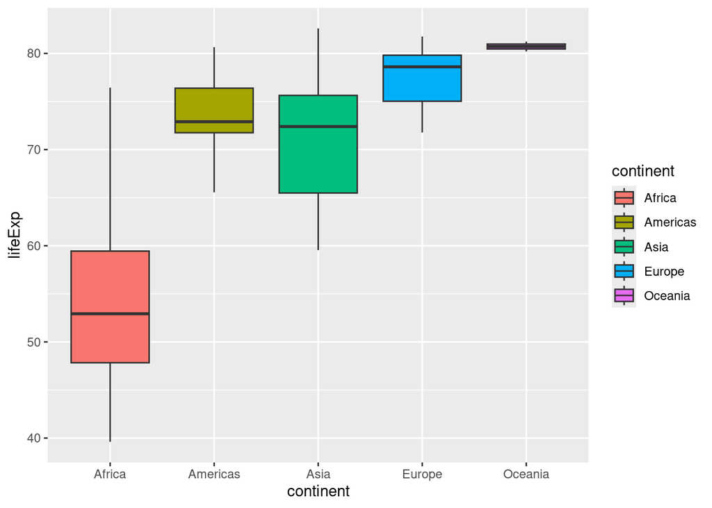

```r
ggplot(data = gapminder_2007,
       mapping = aes(x = continent,
                     y = lifeExp,
                     fill = continent)) +
  geom_boxplot(outlier.shape = NA)
```

## Task 7: Create a timeseries plot

1. A code chunk has already been created.
2. Use the `ggplot()` function and the `gapminder_summary_continent_year` object to create a connected scatterplot (also called timeseries plot) using the `geom_line()` and `geom_point()`functions with the following aesthetic mappings:
- year to the x-axis;
- life expectancy to the y-axis;
- continent to color using the `color = continent` argument inside `aes()`
3. Run the code contained in the code chunk and fix any errors.

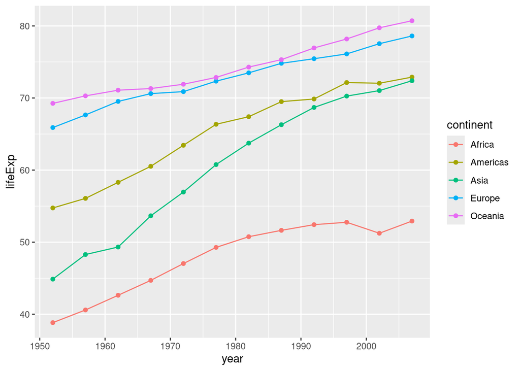

```r
ggplot(data = gapminder_summary_continent_year,
       mapping = aes(x = year,
                     y = lifeExp,
                     colour = continent)) +
  geom_line()+
  geom_point()
```

## Task 8: Create a barplot

### with `geom_col()`

1. A code chunk has already been created.
2. Use the `ggplot()` function and the `gapminder_summary_2007` object to create a barplot using the `geom_col()` function with the following aesthetic mappings:
- continent to the x-axis;
- count to the y-axis;
3. Run the code contained in the code chunk and fix any errors.

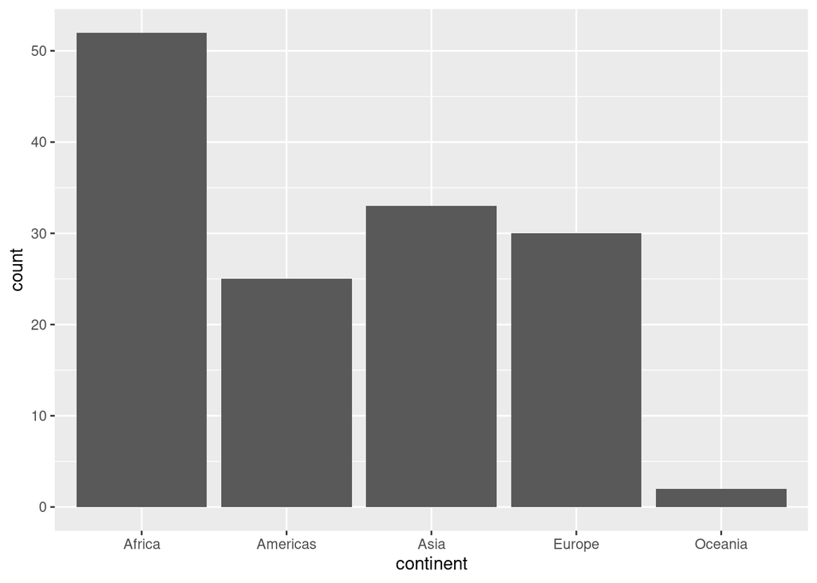

```r
ggplot(data = gapminder_summary_2007,
       mapping = aes(x = continent,
                     y = count)) +
geom_col()
```

### with `geom_bar()`

1. A code chunk has already been created.
2. Use the `ggplot()` function and the `gapminder_2007` object to create a barplot using the `geom_bar()` function with the following aesthetic mappings:
- continent to the x-axis;
3. Run the code contained in the code chunk and fix any errors.
4. The plot is identical to the plot created with `geom_col()`. Why? What does the `geom_bar()` function do? Write your text here:

calculates counts automatically. doesnt need grouped data.

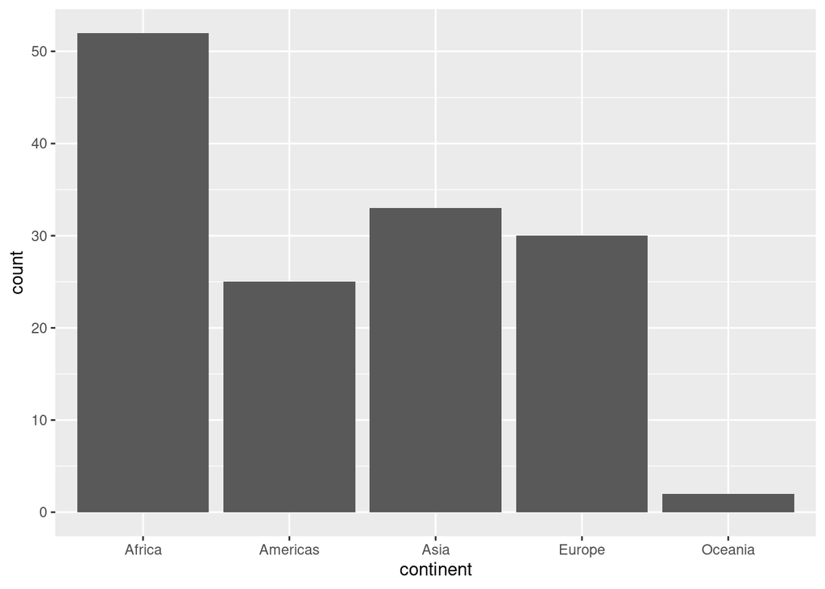

```r
ggplot(data = gapminder_2007,
       mapping = aes(x = continent))+

  geom_bar()
```

## Task 9: Create a histogram

1. A code chunk has already been created.
2. Use the `ggplot()` function and the `gapminder_2007` object to create a histogram using the `geom_histogram()` function with the following aesthetic mappings:
- life expectancy to the x-axis;
- continent to color using the `fill = continent` argument inside `aes()`
3. Run the code contained in the code chunk and fix any errors.
4. Inside the `geom_histogram()` function, add the following arguments and values:
- `col = "grey30"`
- `breaks = seq(40, 85, 2.5)`
5. Run the code contained in the code chunk and fix any errors.
6. Describe how the `geom_histogram()` function is similar to the `geom_bar()` function.
7. What happens by adding the ‘breaks’ argument? Play around with the numbers inside of `seq()` to see what changes. Describe here what you observe:

start and end lifeExp number and distance between each bar.

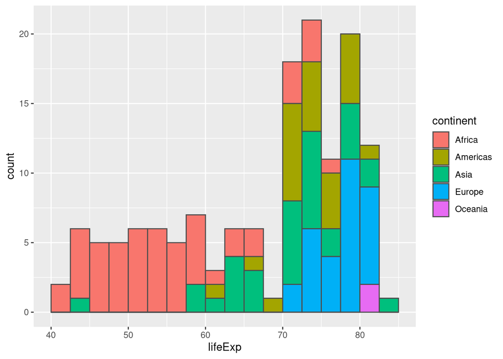

```r
ggplot(data = gapminder_2007,
       mapping = aes(x = lifeExp,
                     fill = continent)) +
  geom_histogram(col = "grey30",
                 breaks = seq(40, 85, 2.5))
```

## Task 10: Scatterplot and faceting

1. A code chunk has already been created.
2. Use the `ggplot()` function and assign `gapminder_2007` and create a scatterplot using the `geom_point()`function with the following aesthetic mappings:
- gdpPercap the x-axis;
- lifeExp to the y-axis;
- population to the size argument;
- country to color using the `color = country` argument inside `aes()`
4. Run the code contained in the code chunk and fix any errors.
5. Use the variable continent to facet the plot by adding: `facet_wrap(~continent)`.
6. Edit `geom_point()` to remove the legend: `geom_point(show.legend = FALSE)`
7. Run the code contained in the code chunk and fix any errors.

[figure not shown]

```r
ggplot(data = gapminder_2007,
       mapping = aes(x = gdpPercap,
                     y = lifeExp,
                     size = pop,
                     color = country))+
  geom_point()
```

## Task 11: Create a lineplot and use facets

1. A code chunk with complete code has already been prepared.
2. Run the code contained in the code chunk and fix any errors.
3. Remove the ‘#’ sign at the line that starts with the `scale_color_manual()` function
4. What is stored in the `country_colors` object? Find out by executing the object in the Console (type it to the Console and hit enter). Do the same again, but with a question mark `?country_colors`.
5. Next to the code chunk option `#| eval:` change the value from `false` to `true`.
6. Render the document and fix any errors.

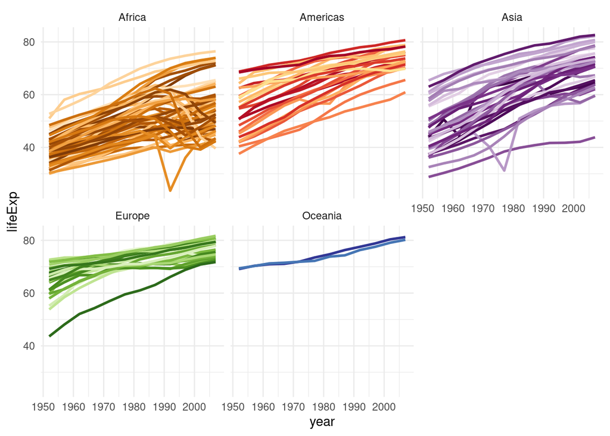

```r
ggplot(data = gapminder,
       mapping = aes(x = year,
                     y = lifeExp,
                     group = country,
                     color = country)) +
  geom_line(lwd = 1, show.legend = FALSE) +
  facet_wrap(~continent) +
  scale_color_manual(values = country_colors) +
  theme_minimal()
```

## Task 12: Create a choropleth Maps

You can also prepare maps with `ggplot2`. It’s beyond the scope of the class to teach you the foundations of spatial data in R, but a popular package to work with spatial data is the `sf` (Simple Features) R Package. The `rnaturalearth` R Package facilitates world mapping by making [Natural Earth](https://www.naturalearthdata.com/) map data more easily available to R users.

The code chunk below contains code for a world map that shows countries by income group. To view the map, do the following:

1. Run the code contained in the code chunk and fix any errors.
2. Next to the code chunk option `#| eval:` change the value from `false` to `true`.
3. Render the document and fix any errors.

```r
world <- ne_countries(scale = "small", returnclass = "sf")

world |>
  mutate(income_grp = factor(income_grp, ordered = T)) |>
  ggplot(aes(fill = income_grp)) +
  geom_sf() +
  theme_void() +
  theme(legend.position = "top") +
  labs(fill = "Income Group:") +
  guides(fill = guide_legend(nrow = 2, byrow = TRUE))
```

[output not shown]

The code for the code chunk is taken from here: More here: https://bookdown.org/alhdzsz/data_viz_ir/maps.html

### Working with spatial data in R

If you are interested in working with spatial data in R, then we recommend the following resources for further study:

- Geocompuation with R - Book: https://geocompr.robinlovelace.net/
- Simple Features for R - Article: https://r-spatial.github.io/sf/articles/sf1.html
- tmap: thematic maps in R - R Package: https://r-tmap.github.io/tmap/

## Task 13: Data communication

**In the YAML header (between the three dashes at the top of the document)**

1. Add your name as the author of this document
2. Render the document and fix any errors

## Task 14: Complete assignment

### Stage, Commit & Push to GitHub

1. Open the Git pane in RStudio. It’s in the top right corner in a separate tab.
2. **Stage** your changes by checking appropriate box next to all files (if you select one file with your mouse, you can then highlight them all with Ctrl + A on your keyboard and check all boxes)
3. Write a meaningful commit message (e.g. “Completed homework assignment 02.) in the **Commit message** box
4. Click **Commit**. Note that every commit needs to have a commit message associated with it.

### Open an issue on GitHub

1. Open [github.com](https://github.com/) in your browser.
2. Navigate to the GitHub organisation for the course.
3. Find the repository md-02-assignments that ends with your GitHub username.
4. Click on the “Issues” tab.
5. Click on the green “New issue” button.
6. In the “Title” field write: “Completed module 2 assignments”.
7. In the “Leave a comment” field, tag the course instructors @larnsce and ask some questions.